# Inference for many proportions

## \(\chi^2\) Goodness of Fit

| Ethnicity | Asian | Black | Hispanic | White | Other | Total |
| --- | --- | --- | --- | --- | --- | --- |
| Obs. count | 49 | 10 | 34 | 206 | 55 | 354 |
| Exp. count | 15.22 | 7.08 | 44.25 | 272.58 | 14.87 | 354 |

## Question

Which of the following is an appropriate null hypothesis?

1. Ethnic diversity and choice of college are independent of one another.
2. Ethnic diversity and home-state are independent of one another.
3. \(p_{asian} = p_{black} = p_{hispanic} = p_{white} = p_{other}\).
4. The first-year class at Reed is sampled from a population that shares the same ethnic distribution as Oregon.

## Goodness of Fit Test

**\(H_0\)**: The first-year class at Reed is sampled from a population that shares *the same* ethnic distribution as Oregon.

**\(H_A\)**: The first-year class at Reed is sampled from a population that has a *different* ethnic distribution than Oregon.

## Constructing the Null Distribution

1. **Simulation**: simulate many first-year Oregonian Reedie classes and calculate the \(\chi^2\) for each.
2. **Probability Theory**: multinomial distribution. \(X \sim \textrm{multinom}(n, p_1, p_2, p_3, p_4, p_5)\).
3. **Chi-Squared Approximation**: if conditions are reasonable, the \(\chi^2\) will follow a known distribution under the null hypothesis.

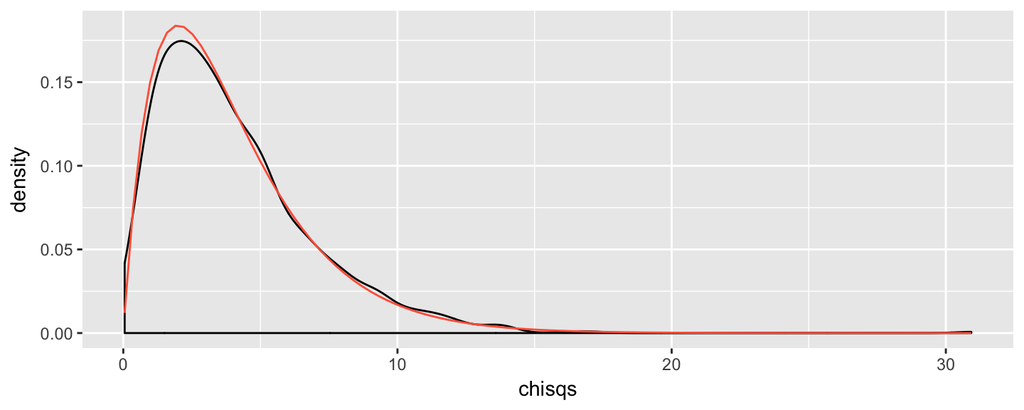

## Conditions for the \(\chi^2\) approximation

1. Independent observations
2. Each expected cell count is \(\ge\) 5
3. \(k \ge 3\)

then our statistic can be well-approximated by the \(\chi^2\) distribution with \(k - 1\) degrees of freedom.

## Finding a p-value

### Table

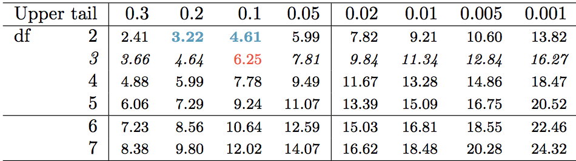

### R

```r
1 - pchisq(139.64, df = 4)
```

```
## [1] 0
```

We reject the hypothesis that the Reed first-year class represents a random sample from Oregon w.r.t ethnicity.

## Degrees of Freedom

*The number of independent ways by which a dynamic system can move, without violating any constraint imposed on it.* (wikipedia)

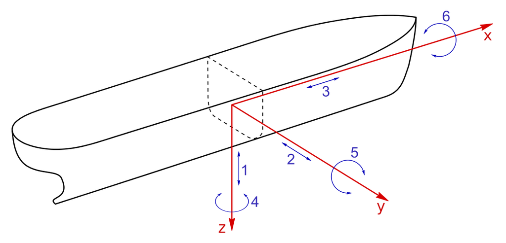

## Degrees of Freedom

*The number of parameters that are free to vary, without violating any constraint imposed on it*.

### Parameters

\[ p_{asian}, p_{black}, p_{hispanic}, p_{white}, p_{other} \]

Since \(\sum_{i = 1}^k p_i = 1\), one of our parameters is contrained, leaving \(k-1\) that are free to vary.

## Shape of the \(\chi^2\)

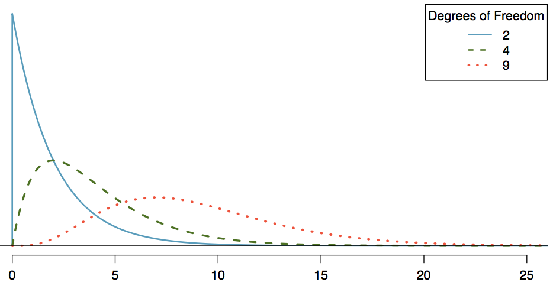

## Confidence Intervals for \(\chi^2\)

These make no sense. Why not?

- We don't really care what the *true* \(\chi^2\) parameter value is.
- A two-sided interval wouldn't make sense
  - Distribution is bounded on the left by zero
  - Only "extreme" values are in the right tail

## \(\chi^2\) Independence

## Example: Acupuncture

```r
treatment <- rep(c("acu", "sham", "trad"), c(387, 387, 388))
pain <- c(rep(c("reduc", "noreduc"), c(184, 203)),
          rep(c("reduc", "noreduc"), c(171, 216)),
          rep(c("reduc", "noreduc"), c(106, 282)))
table(pain, treatment)
```

```
##          treatment
## pain      acu sham trad
##   noreduc 203  216  282
##   reduc   184  171  106
```

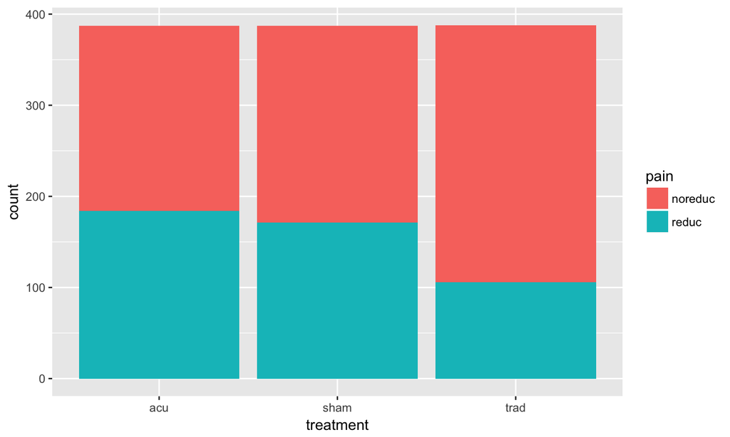

```r
library(ggplot2)
qplot(x = treatment, fill = pain, geom = "bar")
```

## Constructing the Null Distribution

\(H_0\) implies that the associations between these two vectors are just due to chance, so we mirror that by randomizing the vectors to get another possible data set under the \(H_0\).

### Randomization method

```r
chisqs <- rep(0, 1000)
set.seed(405)
for(i in 1:1000) {
  shuffled_pain <- sample(pain)
  new_tab <- table(shuffled_pain, treatment)
  chisqs[i] <- chisq.test(new_tab)$statistic
}
```

## Randomized Null Distribution

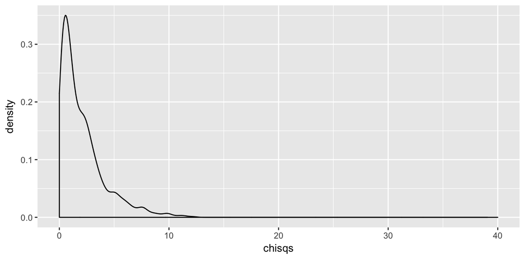

## Randomized Null Distribution

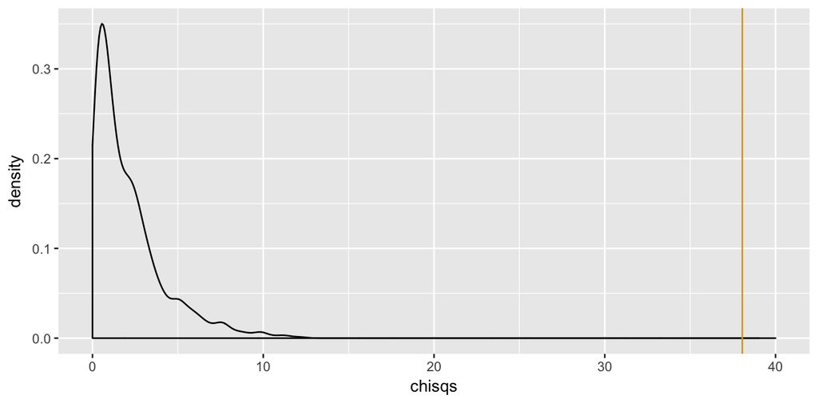

The proportion of simulated \(\chi^2\) statistics under \(H_0\) that are greater than \(\chi^2_{obs}\) is 0 \(\rightarrow\) we reject the idea that pain is independent of treatment mode.

## Using the \(\chi^2\) approximation

The mathematical approximation is good enough when

1. Independent observations
2. At least 5 expected counts in each cell
3. Degrees of freedom \(\ge 2\)

\[ df = (R - 1) \times (C - 1) \]

- \(R\): number of rows in table
- \(C\): number of columns in table

## \(\chi^2\) approximation

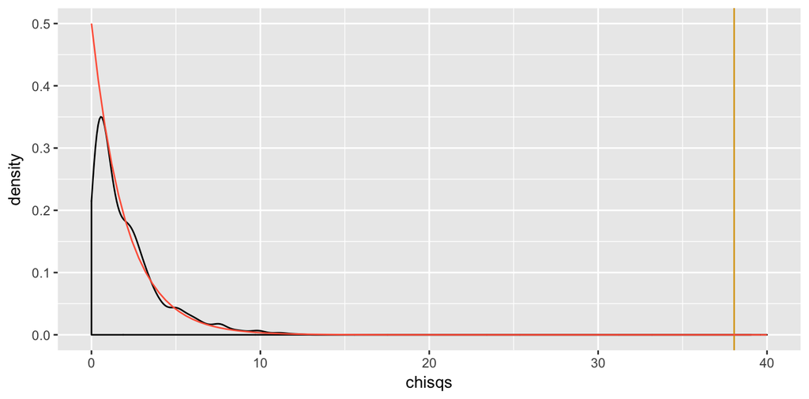

```r
1 - pchisq(38.05, df = 2)
```

```
## [1] 5.46e-09
```

## inference function

```r
inference(x = treatment, y = pain, data = d, statistic = "proportion", type = "ht",
          method = "theoretical")
```

```
## Response variable: categorical (2 levels)
## Explanatory variable: categorical (3 levels)
## Observed:
##       y
## x      noreduc reduc
##   acu      203   184
##   sham     216   171
##   trad     282   106
##
## Expected:
##       y
## x      noreduc reduc
##   acu      233   154
##   sham     233   154
##   trad     234   154
##
## H0: treatment and pain are independent
## HA: treatment and pain are dependent
## chi_sq = 38.0541, df = 2, p_value = 0
```

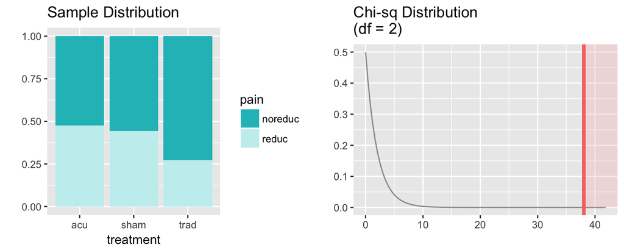

## What have we learned about pain reduction?

- Pain reduction *does* appear to be effected by the treatment method.
- We don't yet know which pairwise comparisons are significant \(\rightarrow\) need to follow up with CIs on the differences in proportions.